# Datamining

OH HYUN JIN

2019년 5월 24일

# 데이터 불러오기

```r
setwd("C:\\Users\\현진\\Desktop")
data <- read.csv("diabetes.csv", header=TRUE, stringsAsFactors=FALSE)
```

# 데이터 변수명 설정 및 설명

```r
variable.type <- lapply(data, class)
variable.description <- c("Number of times pregnant",  "Plasma glucose concentration at 2 hours in an oral glucose tolerance test", "Diastolic blood pressure", "Triceps skin fold thickness", "2-hour serum insulin (µU/ml)", "Body Mass Index", "Synthesis of the history of Diabetes Mellitus in relatives, generic  relationship of those relatives to the subject", "Age of the individual",  "Occurrence of Diabetes")
variable.name <- colnames(data)
datadesc <- as.data.frame(cbind(variable.name, variable.type, variable.description))
colnames(datadesc) <- c("Variable Name","Data Type","Variable Description")
```

# 테이블 형식으로 정리

```r
library("knitr")
kable(datadesc)
```

|  | Variable Name | Data Type | Variable Description |
| --- | --- | --- | --- |
| Pregnancies | Pregnancies | integer | Number of times pregnant |
| Glucose | Glucose | integer | Plasma glucose concentration at 2 hours in an oral glucose tolerance test |
| BloodPressure | BloodPressure | integer | Diastolic blood pressure |
| SkinThickness | SkinThickness | integer | Triceps skin fold thickness |
| Insulin | Insulin | integer | 2-hour serum insulin (μU/ml) |
| BMI | BMI | numeric | Body Mass Index |
| DiabetesPedigreeFunction | DiabetesPedigreeFunction | numeric | Synthesis of the history of Diabetes Mellitus in relatives, generic relationship of those relatives to the subject |
| Age | Age | integer | Age of the individual |
| Outcome | Outcome | integer | Occurrence of Diabetes |

# 데이터 전처리

```r
#Dealing with zeros
missing_data <- data[,setdiff(names(data), c('Outcome', 'Pregnancies'))]
features_miss_num <- apply(missing_data, 2, function(x) sum(x <= 0))
features_miss <- names(missing_data) [features_miss_num > 0]
```

```r
rows_miss <- apply(missing_data, 1, function(x) sum(x <= 0) >=1)
sum(rows_miss)
```

```
## [1] 376
```

```r
missing_data[missing_data <= 0] <- NA
data[, names(missing_data)] <- missing_data
```

```r
#KNN imputation
orig_data <- data
colSums(is.na(data))
```

```
##              Pregnancies                  Glucose            BloodPressure
##                        0                        5                       35
##            SkinThickness                  Insulin                      BMI
##                      227                      374                       11
## DiabetesPedigreeFunction                      Age                  Outcome
##                        0                        0                        0
```

```r
library("DMwR")
data[,c(-8, -9)] <- knnImputation(data[,c(-8, -9)], k=5)

data$Outcome <- factor(data$Outcome)
```

# 데이터 탐색

1. 반응변수

결과

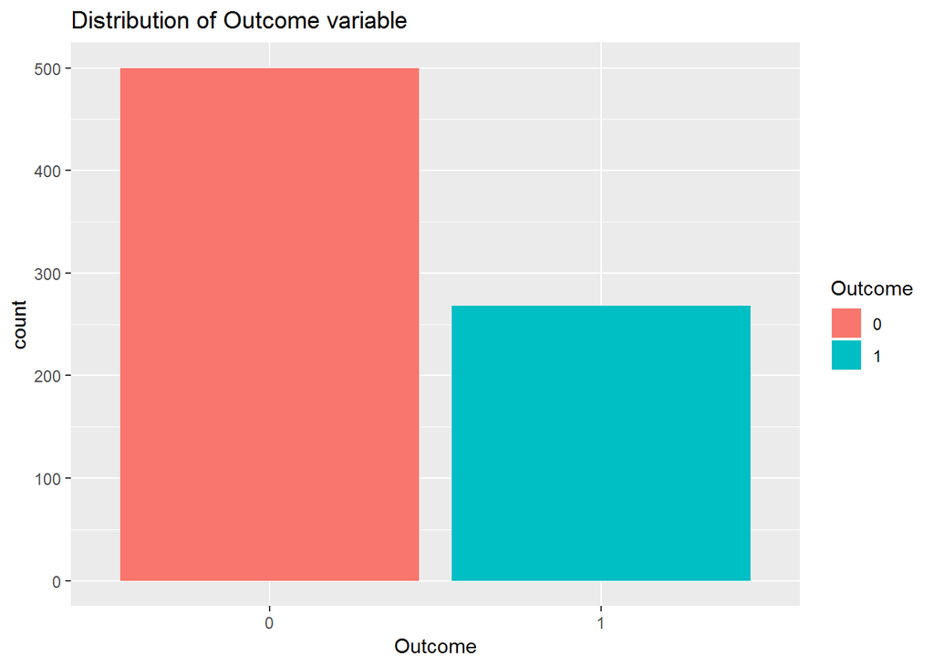

```r
#1. OUtcome
library("ggplot2")
ggplot(data,aes(Outcome, fill = Outcome)) +
  geom_bar() +
  ggtitle("Distribution of Outcome variable")
```

예측변수

2.임신

당뇨병 진단을 받은 여성들이 그렇지 않은 여성들보다 더 많은 임신을 한 것을 알 수 있다. 그리고 히스토그램을 보면 임신수와 당뇨병 발생 사이에 명확한 관계가 없는 것을 알 수 있다.

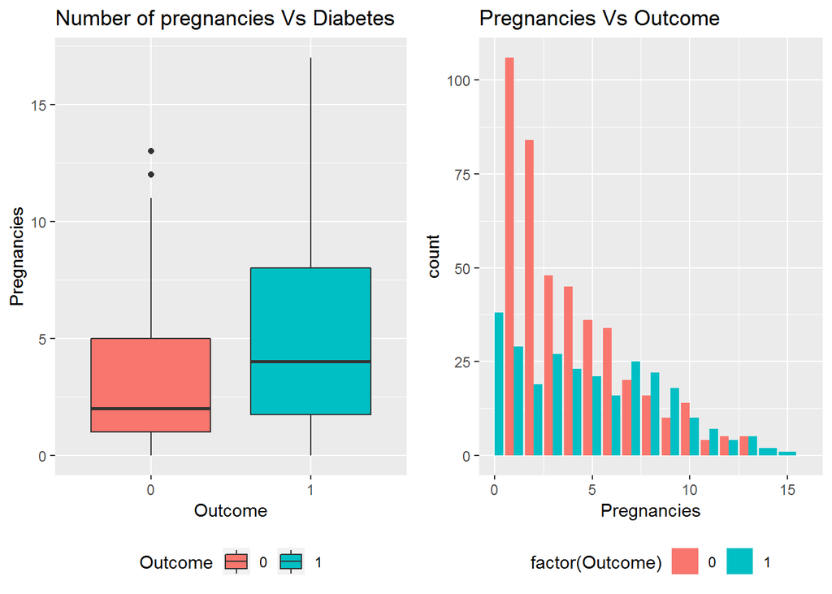

```r
#2. Pregnancies
p1 <- ggplot(data, aes(x = Outcome, y = Pregnancies, fill=Outcome)) +
  geom_boxplot() +
  theme(legend.position = "bottom") +
  ggtitle("Number of pregnancies Vs Diabetes")

p2 <- ggplot(data, aes(x = Pregnancies, fill= factor(Outcome))) +
  geom_bar(position = "Dodge") +
  scale_x_continuous(limits=c(0,16)) +
  theme(legend.position = "bottom") +
  labs(title ="Pregnancies Vs Outcome")

gridExtra::grid.arrange(p1, p2, ncol=2)
```

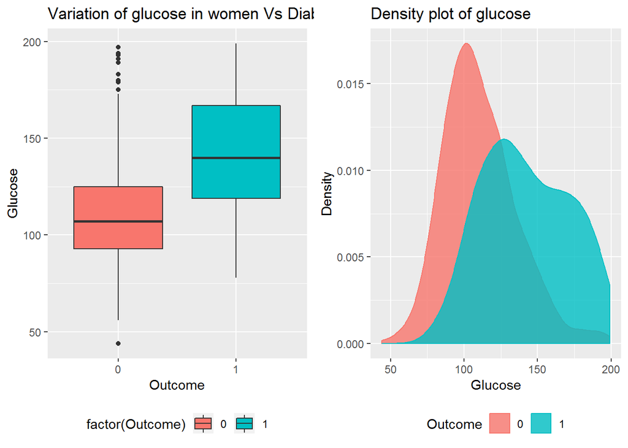

```r
#2. Pregnancies
p2 <- ggplot(data, aes(x = Glucose, color = Outcome, fill=Outcome)) +
  geom_density(alpha = 0.8) +
  theme(legend.position = "bottom") +
  labs(x = "Glucose", y = "Density", title ="Density plot of glucose")

p1 <- ggplot(data, aes(x = Outcome, y = Glucose, fill= factor(Outcome))) +
  geom_boxplot() +
  theme(legend.position = "bottom") +
  ggtitle("Variation of glucose in women Vs Diabetes")

gridExtra::grid.arrange(p1, p2, ncol=2)
```

3. 혈압

아래 그림을 보면 당뇨병을 가지고 있는 여성과 그렇지 않은 여성의 두 범주에는 뚜렷한 차이가 보이지 않는다. 이것은 혈압이 반응 변수의 좋은 예측 변수가 아닐 수도 있다는 것을 보여준다.

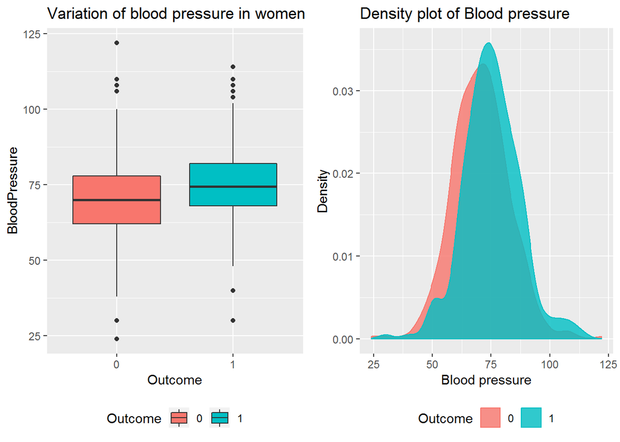

```r
# 3. Blood Pressure
p2 <- ggplot(data, aes(x = BloodPressure, color = Outcome, fill = Outcome)) +
  geom_density(alpha = 0.8) +
  theme(legend.position = "bottom") +
  labs(x = "Blood pressure", y = "Density", title = "Density plot of Blood pressure")

p1 <- ggplot(data, aes(x = Outcome, y = BloodPressure,fill = Outcome)) +
  geom_boxplot() +
  theme(legend.position = "bottom") +
  ggtitle("Variation of blood pressure in women Vs Diabetes")

gridExtra::grid.arrange(p1, p2, ncol = 2)
```

4. 피부 두께

아래 그림을 보면 당뇨병을 가지고 있는 여성과 그렇지 않은 여성의 두 범주에 뚜렷한 차이가 없다. 이 또한 아까와 마찬가지로 피부 두께가 반응 변수의 좋은 예측 변수가 아닐 수 있다는 것을 보여준다.

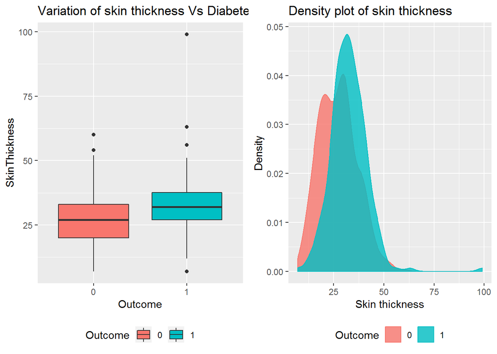

```r
# 4. Skin Thickness
p2 <- ggplot(data, aes(x = SkinThickness, color = Outcome, fill = Outcome)) +
  geom_density(alpha = 0.8) +
  theme(legend.position = "bottom") +
  labs(x = "Skin thickness", y = "Density", title = "Density plot of skin thickness")

p1 <- ggplot(data, aes(x = Outcome, y = SkinThickness,fill = Outcome)) +
  geom_boxplot() +
  theme(legend.position = "bottom") +
  ggtitle("Variation of skin thickness Vs Diabetes")

gridExtra::grid.arrange(p1, p2, ncol = 2)
```

5. 인슐린

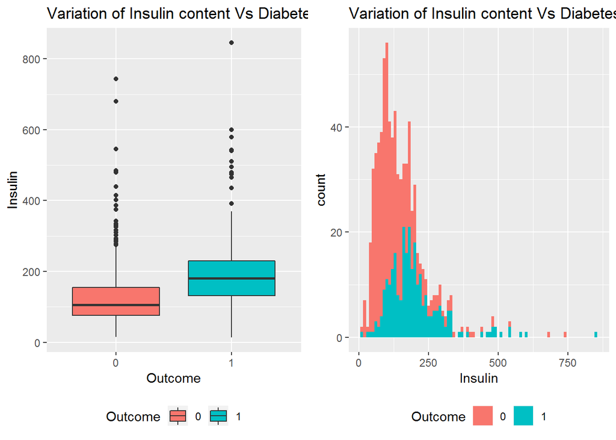

```r
# 5. Insulin
p1 <- ggplot(data, aes(x = Outcome, y = Insulin, fill = Outcome)) +
  geom_boxplot() +
  theme(legend.position = "bottom") +
  ggtitle("Variation of Insulin content Vs Diabetes")

p2 <- ggplot(data, aes(Insulin, fill = Outcome)) +
  geom_histogram(binwidth=10) +
  theme(legend.position = "bottom") +
  ggtitle("Variation of Insulin content Vs Diabetes")

gridExtra::grid.arrange(p1, p2, ncol = 2)
```

6. BMI

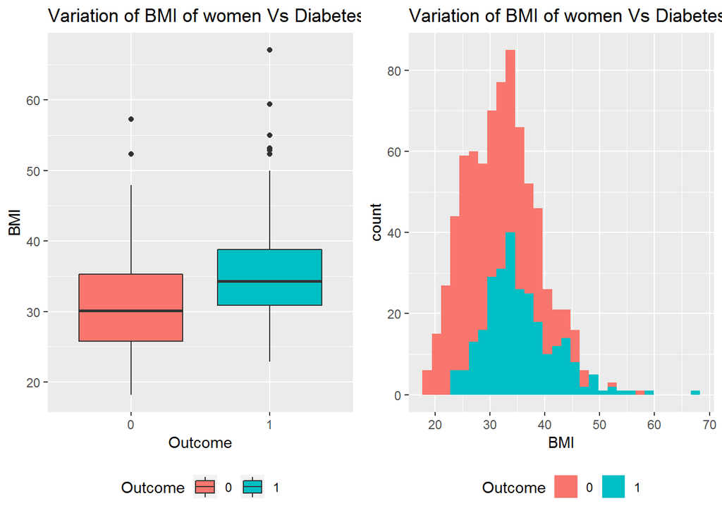

```r
# 6. BMI
p2 <- ggplot(data, aes(BMI, fill = Outcome)) +
  geom_histogram() +
  theme(legend.position = "bottom") +
  ggtitle("Variation of BMI of women Vs Diabetes")

p1 <- ggplot(data, aes(x = Outcome, y = BMI, fill = Outcome)) +
  geom_boxplot(binwidth = 5) +
  theme(legend.position = "bottom") +
  ggtitle("Variation of BMI of women Vs Diabetes")
gridExtra::grid.arrange(p1, p2, ncol = 2)
```

7. 당뇨/소아 기능

당뇨병을 가지고 있는 여성과 그렇지 않은 여성의 두가지 범주에서 뚜렷한 차이를 발견할 수 없었다. 이는 DPF 또한 반응변수의 좋은 예측 변수가 아닐 수 있다는 것을 보여준다.

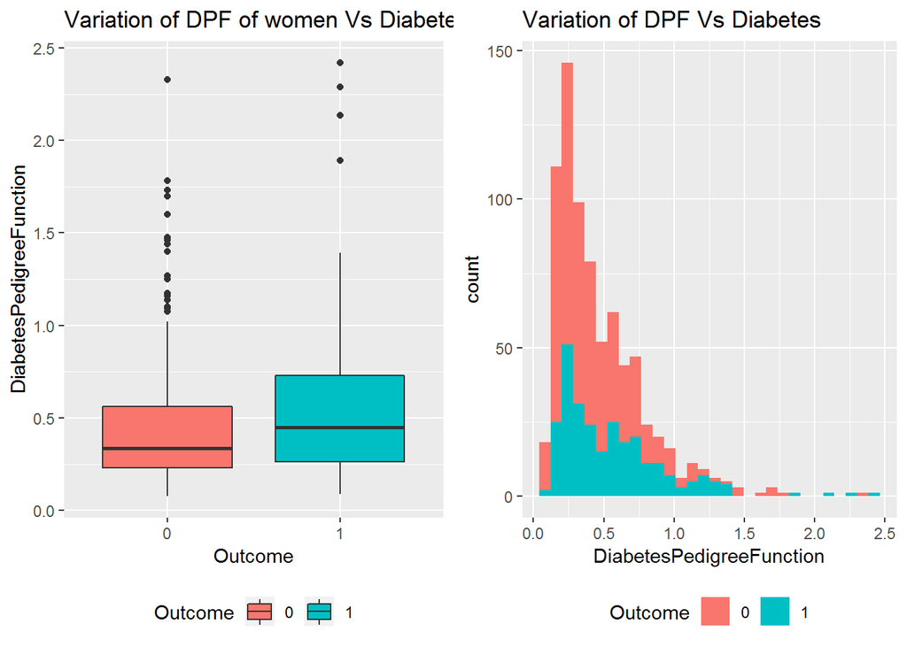

```r
# 7. DPF
p1 <- ggplot(data, aes(x = Outcome, y = DiabetesPedigreeFunction,fill = Outcome)) +
  geom_boxplot() +
  theme(legend.position = "bottom") +
  ggtitle("Variation of DPF of women Vs Diabetes")


p2 <- ggplot(data, aes(DiabetesPedigreeFunction,fill = Outcome)) +
  geom_histogram() +
  theme(legend.position = "bottom") +
  ggtitle("Variation of DPF Vs Diabetes")

gridExtra::grid.arrange(p1, p2, ncol = 2)
```

8. 나이

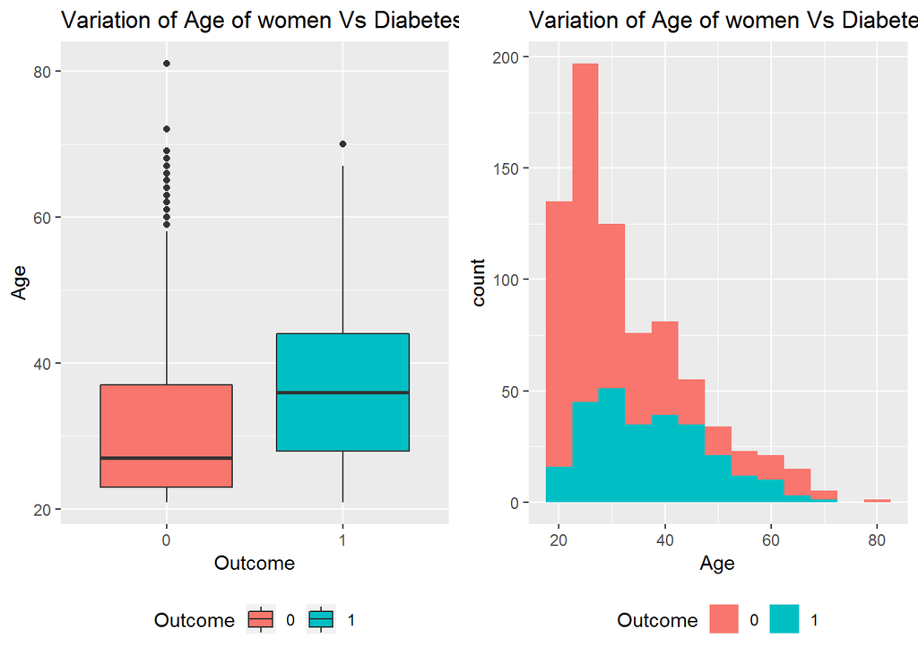

```r
# 8. Age
p2 <- ggplot(data, aes(Age, fill = Outcome)) +
  geom_histogram(binwidth = 5) +
  theme(legend.position = "bottom") +
  ggtitle("Variation of Age of women Vs Diabetes")

p1 <- ggplot(data, aes(x = Outcome, y = Age,fill = Outcome)) +
  geom_boxplot() +
  theme(legend.position = "bottom") +
  ggtitle("Variation of Age of women Vs Diabetes")

gridExtra::grid.arrange(p1, p2, ncol = 2)
```

# 생물학적 연관성

생물학적 연관성에서, 다음과 같은 추론을 할 수 있다.

1. 남녀가 아닌 여성과 당뇨가 없는 여성을 연령대별로 구분하는 명확한 경계선은 없다.
2. 당뇨병에 걸리지 않은 여성들은 인슐린과 포도당 수치가 낮거나 높은 것으로 기록된 당뇨병 여성들에 비해 인슐린 포도당 수치가 낮은 것으로 보인다.

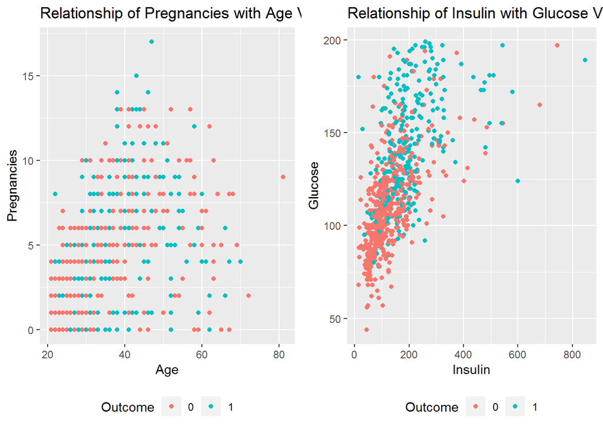

```r
p1 <- ggplot(data, aes(x = Age, y = Pregnancies)) +
  geom_point(aes(color=Outcome)) +
  theme(legend.position = "bottom") +
  ggtitle("Relationship of Pregnancies with Age Vs Diabetes")
#
p2 <- ggplot(data,aes(x=Insulin,y=Glucose))+
  geom_point(aes(color=Outcome))+
  theme(legend.position = "bottom") +
  ggtitle("Relationship of Insulin with Glucose Vs Diabetes")

gridExtra::grid.arrange(p1, p2, ncol = 2)
```

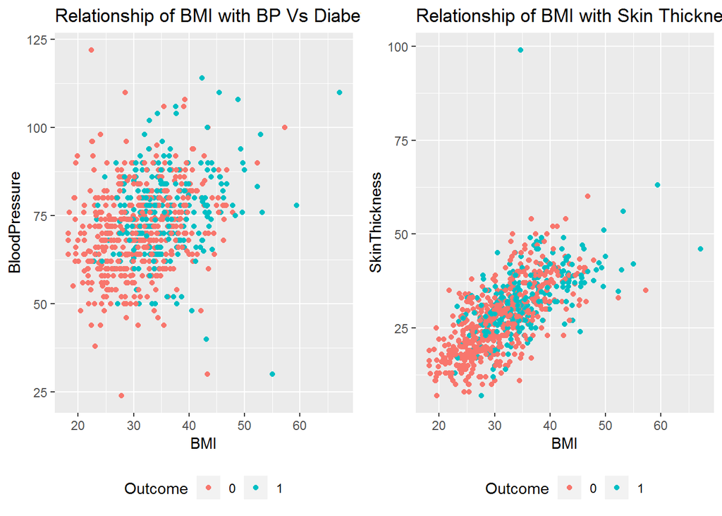

```r
p1 <- ggplot(data,aes(x=BMI,y=BloodPressure))+
  geom_point(aes(color=Outcome))+
  theme(legend.position = "bottom") +
  ggtitle("Relationship of BMI with BP Vs Diabetes")

p2 <- ggplot(data,aes(x=BMI,y=SkinThickness))+
  geom_point(aes(color=Outcome))+
  theme(legend.position = "bottom") +
  ggtitle("Relationship of BMI with Skin Thickness Vs Diabetes")

gridExtra::grid.arrange(p1, p2, ncol = 2)
```

# 예측 변수 간의 상관 관계

상호 간의 선형 관계를 설정하기 위해 모든 숫자 변수 사이에 상관 관계도를 그렸을 때 생물 다양성 협회에서 관찰된 바와 같이 인슐린과 포도당, BMI, 피부 두께는 중간에서 높은 선형상관 관계를 보였다.

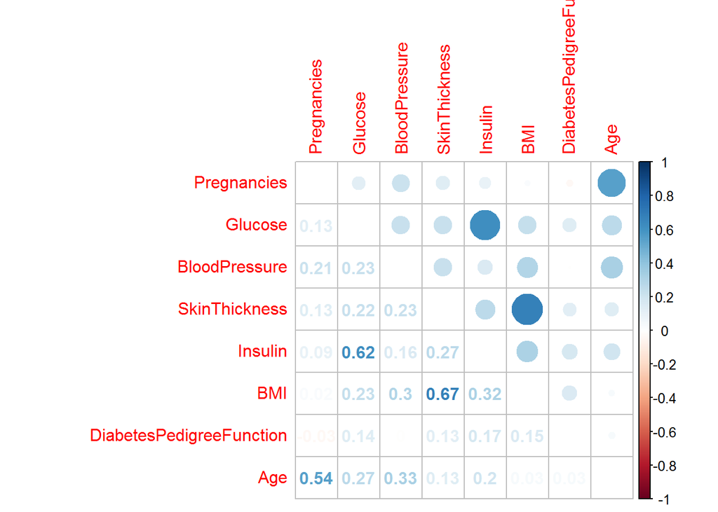

```r
#
library(corrplot)
corMat = cor (data[, -9])
diag (corMat) = 0 #Remove self correlations
corrplot.mixed(corMat,tl.pos = "lt")
```

# 모델링 접근법

여성을 당뇨병이 없는 상태로 분류하는 예측 모델을 구축하기 위해 다음과 같은 모델 접근법을 사용하였습니다.

1. **모델링**

   데이터에 대해 수행되는 모델링 기법에는 로지스틱 회귀 분석, 분류 나무, 랜덤 포레스트, SVM이 포함됩니다.
2. 각 모델에 대해 민감도를 기준으로 80%(샘플 내), 20%(샘플 외)를 평가하였습니다. 민감도는 당뇨병 환자를 정확하게 식별하는 모델의 능력이다. 아래의 행렬에서 민감도는 (True Positive)/(True Positive + Flase Negative)의 비율로 정의된다.

```r
# Create training and testing set
set.seed(12345)
ratio = sample(1:nrow(data), size = 0.20*nrow(data))
test.data = data[ratio,] #Test dataset 20% of total
train.data = data[-ratio,] #Train dataset 80% of total
```

# 모델링

1. 로지스틱 회귀 분석

전체 모형은 결과 값을 반응 변수로 사용하고 나머지 8개 예측 변수를 사용하여 작성하였습니다. 단계별 변수 선택 방법을 사용하여 가장 중요한 변수를 식별하였고 AIC에서 선택한 최종 모델은 아래와 같이 가장 낮은 AIC값인 593.85인 로지스틱 회귀 분석 모델을 생성하였습니다.

```r
# Logistic Regression
model.glm <- glm(Outcome~.,data=train.data,family = binomial)
step_model <- step(model.glm)
```

```
## Start:  AIC=600.7
## Outcome ~ Pregnancies + Glucose + BloodPressure + SkinThickness +
##     Insulin + BMI + DiabetesPedigreeFunction + Age
##
##                            Df Deviance    AIC
## - SkinThickness             1   582.81 598.81
## - Insulin                   1   582.97 598.97
## - BloodPressure             1   582.99 598.99
## - Age                       1   583.34 599.34
## <none>                          582.70 600.70
## - DiabetesPedigreeFunction  1   586.20 602.20
## - Pregnancies               1   595.66 611.66
## - BMI                       1   606.83 622.83
## - Glucose                   1   646.98 662.98
##
## Step:  AIC=598.81
## Outcome ~ Pregnancies + Glucose + BloodPressure + Insulin + BMI +
##     DiabetesPedigreeFunction + Age
##
##                            Df Deviance    AIC
## - Insulin                   1   583.09 597.09
## - BloodPressure             1   583.10 597.10
## - Age                       1   583.42 597.42
## <none>                          582.81 598.81
## - DiabetesPedigreeFunction  1   586.24 600.24
## - Pregnancies               1   595.67 609.67
## - BMI                       1   619.62 633.62
## - Glucose                   1   646.98 660.98
##
## Step:  AIC=597.09
## Outcome ~ Pregnancies + Glucose + BloodPressure + BMI + DiabetesPedigreeFunction +
##     Age
##
##                            Df Deviance    AIC
## - BloodPressure             1   583.40 595.40
## - Age                       1   583.70 595.70
## <none>                          583.09 597.09
## - DiabetesPedigreeFunction  1   586.79 598.79
## - Pregnancies               1   596.06 608.06
## - BMI                       1   624.11 636.11
```

[output cut: 8 more lines]

```
## <none>                          583.40 595.40
## - DiabetesPedigreeFunction  1   587.13 597.13
## - Pregnancies               1   596.19 606.19
## - BMI                       1   625.92 635.92
## - Glucose                   1   683.75 693.75
##
## Step:  AIC=593.85
## Outcome ~ Pregnancies + Glucose + BMI + DiabetesPedigreeFunction
##
##                            Df Deviance    AIC
## <none>                          583.85 593.85
## - DiabetesPedigreeFunction  1   587.72 595.72
## - Pregnancies               1   605.27 613.27
## - BMI                       1   626.00 634.00
## - Glucose                   1   691.67 699.67
```

```r
# Final model using Logistic Regression
model.new <- glm(formula = Outcome ~ Pregnancies + Glucose + BMI + DiabetesPedigreeFunction, family = binomial, data = train.data)

summary(model.new)
```

```
##
## Call:
## glm(formula = Outcome ~ Pregnancies + Glucose + BMI + DiabetesPedigreeFunction,
##     family = binomial, data = train.data)
##
## Deviance Residuals:
##     Min       1Q   Median       3Q      Max
## -2.6551  -0.7302  -0.4086   0.7295   2.1683
##
## Coefficients:
##                           Estimate Std. Error z value Pr(>|z|)
## (Intercept)              -9.161189   0.783300 -11.696  < 2e-16 ***
## Pregnancies               0.138323   0.030588   4.522 6.12e-06 ***
## Glucose                   0.035024   0.003797   9.223  < 2e-16 ***
## BMI                       0.100968   0.016547   6.102 1.05e-09 ***
## DiabetesPedigreeFunction  0.642931   0.328343   1.958   0.0502 .
## ---
## Signif. codes:  0 '***' 0.001 '**' 0.01 '*' 0.05 '.' 0.1 ' ' 1
##
## (Dispersion parameter for binomial family taken to be 1)
##
##     Null deviance: 804.39  on 614  degrees of freedom
## Residual deviance: 583.85  on 610  degrees of freedom
## AIC: 593.85
##
## Number of Fisher Scoring iterations: 5
```

# 로지스틱 회귀 분석 - 모수 조정

위의 전체 모델을 사용하여 교차 검증을 실시하였고 최적의 컷오프 확률을 식별하였습니다. 불균형 비용 함수는 당뇨병 환자를 잘못 식별한 모델을 처벌하는 것으로 정의되었습니다. 정의된 비대칭 비용 함수 사용(거짓 양성의 경우 2:1): Flase Negatives), 최적의 컷오프 확률이 계산되었습니다. 최적의 컷오프 확률은 모델이 가장 낮은 판별율을 가질 확률입니다.

```r
# CV to choose cut-off probability
library("boot")
```

```r
library("rpart.plot")
searchgrid = seq(0.01, 0.6, 0.02)
result = cbind(searchgrid, NA)
cost1 <- function(r, pi) {
  weight1 = 2
  weight0 = 1
  c1 = (r == 1) & (pi < pcut)  #logical vector - true if actual 1 but predict 0 (False Negative)
  c0 = (r == 0) & (pi > pcut)  #logical vector - true if actual 0 but predict 1 (False Positive)
  return(mean(weight1 * c1 + weight0 * c0))
}
```

pcut값이 서로 다른 교차 검증 비용을 플롯하여 위의 수치를 얻었으며, CV 비용 0.3420으로 최적 컷오프 확률로 0.29를 선택하였습니다.

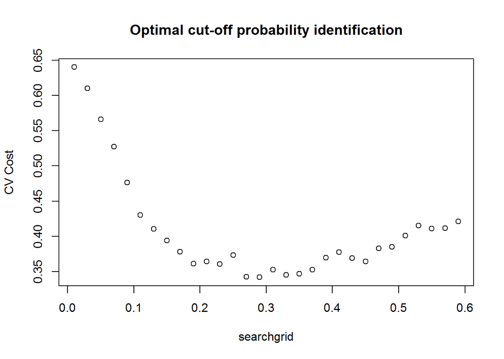

```r
for (i in 1:length(searchgrid)) {
  pcut <- result[i, 1]
  result[i, 2] <- cv.glm(data = train.data, glmfit = model.new, cost = cost1,
                         K = 3)$delta[2]
}
plot(result, ylab = "CV Cost",main = "Optimal cut-off probability identification")
```

# 분류 나무

분류 나무는 반응 변수가 범주형인 경우 데이터 모델링에 사용됩니다. 이 나무는 예측 변수 값 집합에서 가장 중요한 차이를 기준으로 데이터를 2개 이상 동종 집합으로 분할합니다.

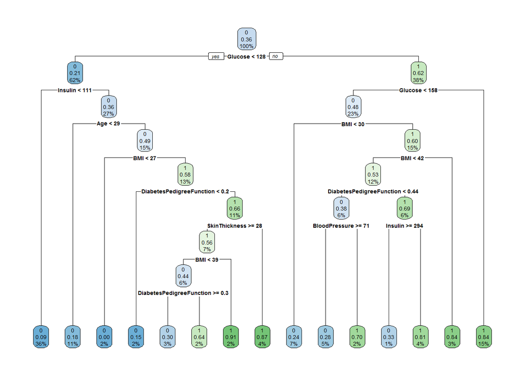

```r
tree.model <- rpart(Outcome~., data=train.data, method="class")
rpart.plot(tree.model)
```

# 분류 나무 - 매개 변수 조정

나무의 복잡성 모수(Cp)는 상대 오차 VSCp의 기준으로 조정되었습니다. 상대적 오차가 크게 감소하지 않는 복잡도 매개 변수 값은 최종 나무의 Cp로 선택되었습니다. 그림에서 0.015의 Cp값을 사용하여 의사 결정 나무를 폐기하였고 최종 결정 나무는 밑의 그림에서 확인할 수 있습니다.

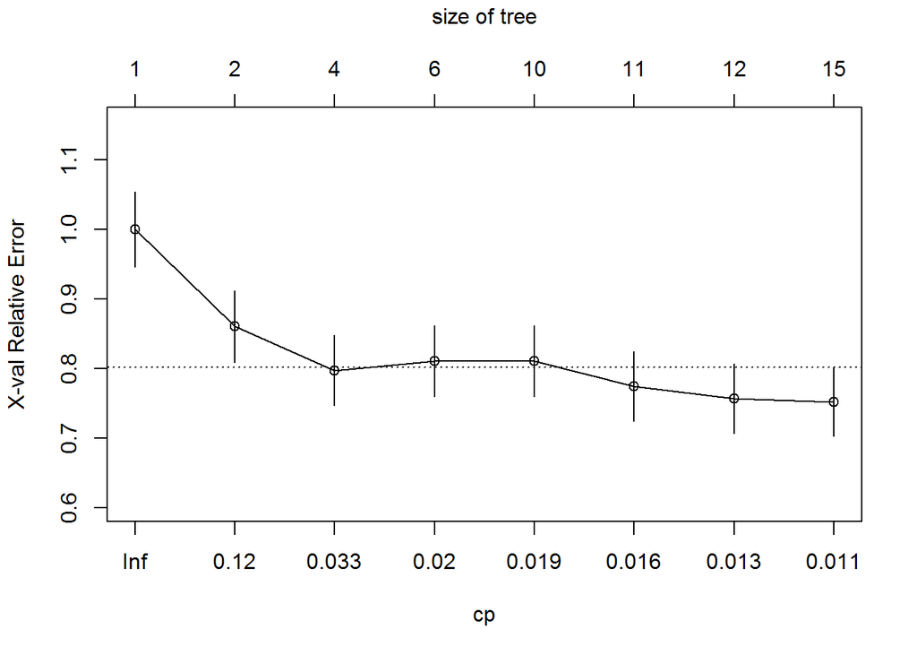

```r
plotcp(tree.model)
```

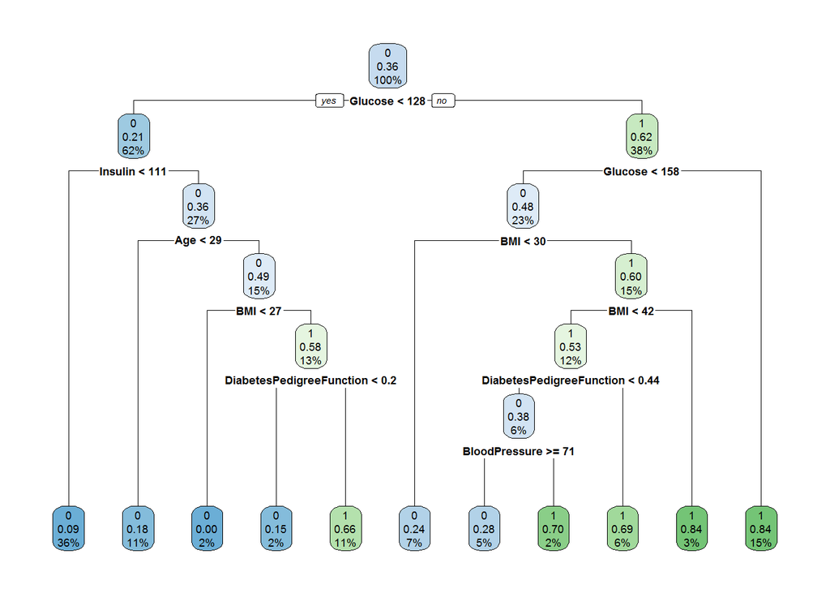

```r
# Optimal cut-off value
# Pruning the tree
tree.model<- rpart(Outcome~., data=train.data, method="class",cp=0.015)
rpart.plot(tree.model)
```

# 랜덤 포레스트

랜덤 포레스트는 다양한 데이터 선택 항목과 나무마다 다른 변수를 선택하여 교육함으로써 많은 의사 결정 나무를 성장시킵니다. 각 나무는 예측 변수와 데이터의 랜덤 부분 집합을 고려하여 결정 변수를 분류합니다. 랜덤 한 숲은 차례로, 최종 결정을 내리기 위한 각각의 나무들의 결정을 결합합니다. MTU매개 변수는 각 나무를 작성하기 위해 선택된 변수의 수 선택을 제어합니다.

```r
#random forest
library("randomForest")
set.seed(1234567)
rf.model <- randomForest(Outcome~., data = train.data, importance=TRUE)
print(rf.model)
```

```
##
## Call:
##  randomForest(formula = Outcome ~ ., data = train.data, importance = TRUE)
##                Type of random forest: classification
##                      Number of trees: 500
## No. of variables tried at each split: 2
##
##         OOB estimate of  error rate: 25.04%
## Confusion matrix:
##     0   1 class.error
## 0 331  62   0.1577608
## 1  92 130   0.4144144
```

# 랜덤 포레스트 - 매개 변수 조정

OOB오류는 양 클래스와 음의 클래스가 전체적으로 잘못 지정된 것을 나타냅니다. 그러나, 현재 예측의 초점은 양의 클래스의 오정화를 줄이는 것이지만, 혼동 매트릭스는 수동으로 비교하였습니다.

```
## mtry = 2  OOB error = 26.34%
## Searching left ...
## mtry = 1     OOB error = 25.2%
## 0.04320988 0.05
## Searching right ...
## mtry = 4     OOB error = 25.85%
## 0.01851852 0.05
```

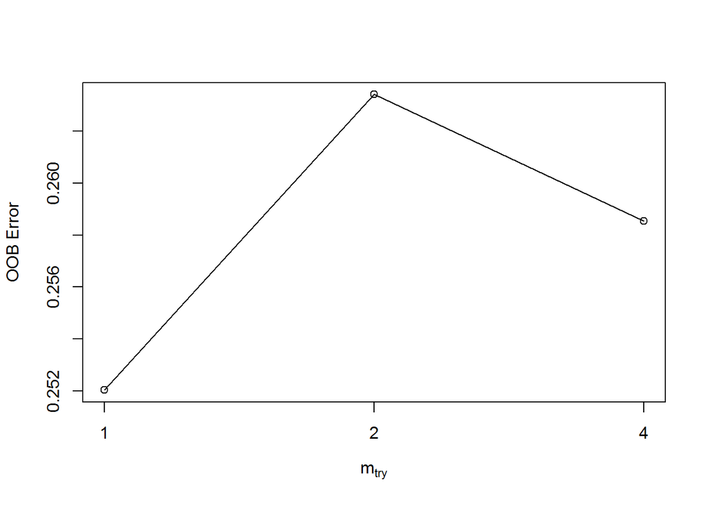

```r
# Tune only mtry parameter using tuneRF()
set.seed(1234567)
res <- tuneRF(x = subset(train.data, select = -Outcome),
              y = train.data$Outcome,
              ntreeTry = 500,
              plot = TRUE, tunecontrol = tune.control(cross = 5))
```

```r
res[res[, 2] == min(res[, 2]), 1]
```

```
## [1] 1
```

```r
#random forest
set.seed(1234567)
rf.model <- randomForest(Outcome~., data = train.data, importance = TRUE, mtry = 4)
rf.model
```

```
##
## Call:
##  randomForest(formula = Outcome ~ ., data = train.data, importance = TRUE,      mtry = 4)
##                Type of random forest: classification
##                      Number of trees: 500
## No. of variables tried at each split: 4
##
##         OOB estimate of  error rate: 25.2%
## Confusion matrix:
##     0   1 class.error
## 0 325  68   0.1730280
## 1  87 135   0.3918919
```

# SVM

SVM은 하이퍼스 플레인과 데이터 포인트 간의 거리를 최대화하여 클래스를 가장 잘 구분하는 하이퍼스 플레인을 식별하는 기술입니다. SVM은 두가지 측면에 중점을 둡니다. 즉, 하이퍼 플렉스와 지원 벡터 간의 최소 마진을 최대화하고 잘못 해석하는 비율을 최소화합니다. 더 큰 비용 함수를 사용하여(잘못 해석하기 위해)SVM은 최소 마진을 타협하는 동시에 응답 변수를 올바르게 분류합니다.

```r
library("e1071")
svm.model <- svm(Outcome~., data = train.data,kernel = "radial", cost = 1, gamma = 0.1,probability = TRUE)
```

# SVM - 매개 변수 조정

```r
#tuning svm
svm_tune <- tune(svm, train.x = train.data[,1:8], train.y = train.data[,9], kernel = "radial",
                 ranges = list(cost = seq(0.1,5,0.1)),tunecontrol = tune.control(cross=5),
                 parms = list(loss = matrix(c(0, 2, 1, 0), nrow = 2)))
svm_tune$best.model
```

```
##
## Call:
## best.tune(method = svm, train.x = train.data[, 1:8], train.y = train.data[,
##     9], ranges = list(cost = seq(0.1, 5, 0.1)), tunecontrol = tune.control(cross = 5),
##     kernel = "radial", parms = list(loss = matrix(c(0, 2, 1,
##         0), nrow = 2)))
##
##
## Parameters:
##    SVM-Type:  C-classification
##  SVM-Kernel:  radial
##        cost:  0.2
##       gamma:  0.125
##
## Number of Support Vectors:  398
```

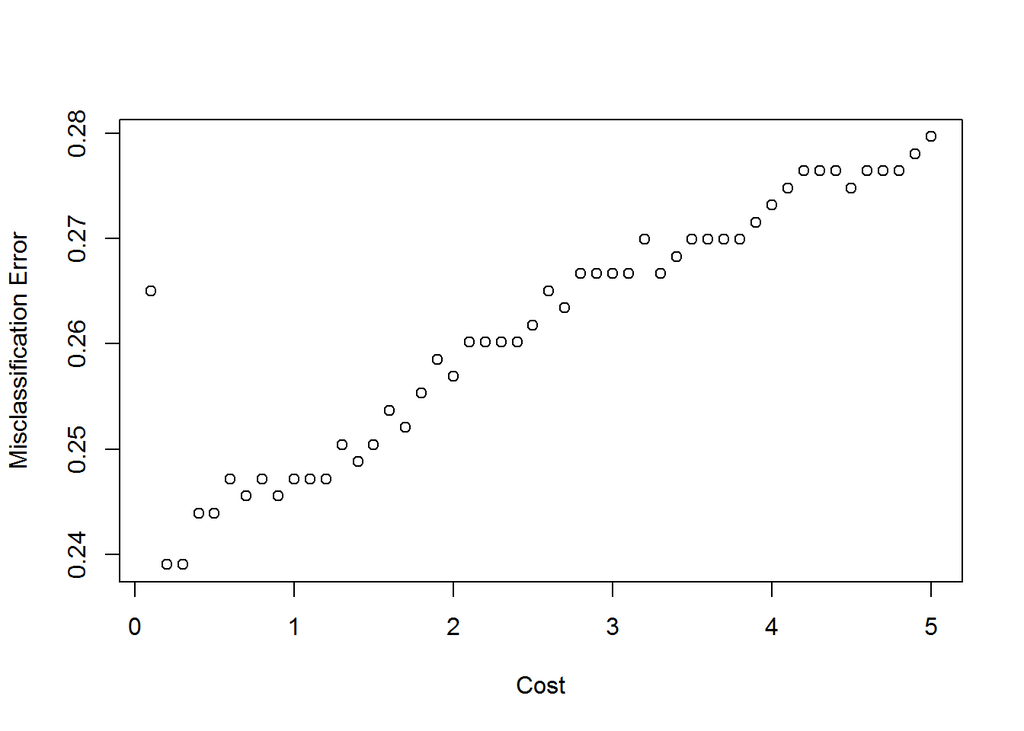

```r
df<-data.frame(svm_tune$performances)
plot(df$cost,df$error,xlab="Cost",ylab="Misclassification Error")
```

```r
svm.model <- svm(Outcome~., data = train.data,kernel = "radial", cost = 0.2, gamma = 0.125,
                 probability = TRUE)
```

# 모델 성능 평가

모델의 성능은 샘플 내 교육 데이터(데이터의 80%)와 샘플 외 테스트 데이터(데이터의 20%)간에 비교되었습니다. 아래 그림에는 모형 성능의 결과가 요약되어 있습니다. 최상의 모델은 비표본 데이터의 성능에 기초하여 선택되었으며 민감도가 의사 결정 기준으로 선택되었습니다.

1. 로지스틱 회귀 분석

```r
# Logistic Regression Performance
library("verification")
```

```r
par(mfrow = c(1,2))

pred.in <- predict(model.new,newdata = train.data,type = "response")
prediction.in <- ifelse(pred.in<0.29,0,1)
tab<-table(as.factor(train.data$Outcome),prediction.in)
roc.plot(train.data$Outcome=="1", pred.in)$roc.vol
```

```
##      Model      Area      p.value binorm.area
## 1 Model  1 0.8388923 1.171605e-44          NA
```

```r
pred.out <- predict(model.new,newdata = test.data,type = "response")
prediction.out <- ifelse(pred.out<0.29,0,1)
table(as.factor(test.data$Outcome),prediction.out)
```

```
##    prediction.out
##      0  1
##   0 71 36
##   1  6 40
```

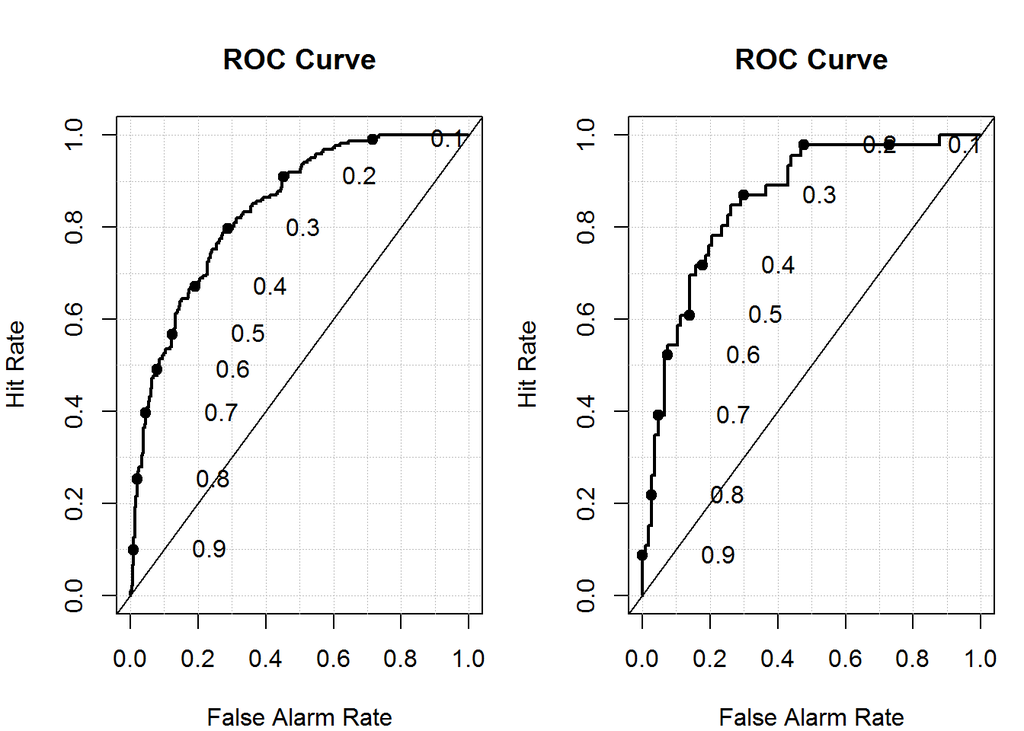

```
##      Model      Area      p.value binorm.area
## 1 Model  1 0.8571719 1.346698e-12          NA
```

```r
roc.plot(test.data$Outcome=="1", pred.out)$roc.vol
```

2. 분류 나무

```r
# Classification Tree Performance
library("caret")
par(mfrow = c(1,2))

tree.predict.in<- predict(tree.model, train.data, type = "class")
tree.pred.in<- predict(tree.model, train.data, type = "prob")
confusionMatrix(train.data$Outcome, tree.predict.in)
```

```
## Confusion Matrix and Statistics
##
##           Reference
## Prediction   0   1
##          0 338  55
##          1  53 169
##
##                Accuracy : 0.8244
##                  95% CI : (0.792, 0.8537)
##     No Information Rate : 0.6358
##     P-Value [Acc > NIR] : <2e-16
##
##                   Kappa : 0.6201
##
##  Mcnemar's Test P-Value : 0.9233
##
##             Sensitivity : 0.8645
##             Specificity : 0.7545
##          Pos Pred Value : 0.8601
##          Neg Pred Value : 0.7613
##              Prevalence : 0.6358
##          Detection Rate : 0.5496
##    Detection Prevalence : 0.6390
##       Balanced Accuracy : 0.8095
##
##        'Positive' Class : 0
##
```

```r
roc.plot(train.data$Outcome== "1", tree.pred.in[,2], ylab = "True Positive Rate", xlab = "False Positive Rate")$roc.vol
```

```
##      Model      Area     p.value binorm.area
## 1 Model  1 0.8542741 3.19379e-51          NA
```

```r
tree.predict<- predict(tree.model, test.data, type = "class")
tree.pred<- predict(tree.model, test.data, type = "prob")
confusionMatrix(test.data$Outcome, tree.predict)
```

```
## Confusion Matrix and Statistics
##
##           Reference
## Prediction  0  1
##          0 84 23
##          1  9 37
##
##                Accuracy : 0.7908
##                  95% CI : (0.7178, 0.8523)
##     No Information Rate : 0.6078
##     P-Value [Acc > NIR] : 1.054e-06
##
##                   Kappa : 0.5423
##
##  Mcnemar's Test P-Value : 0.02156
##
##             Sensitivity : 0.9032
##             Specificity : 0.6167
##          Pos Pred Value : 0.7850
##          Neg Pred Value : 0.8043
##              Prevalence : 0.6078
##          Detection Rate : 0.5490
##    Detection Prevalence : 0.6993
##       Balanced Accuracy : 0.7599
##
##        'Positive' Class : 0
##
```

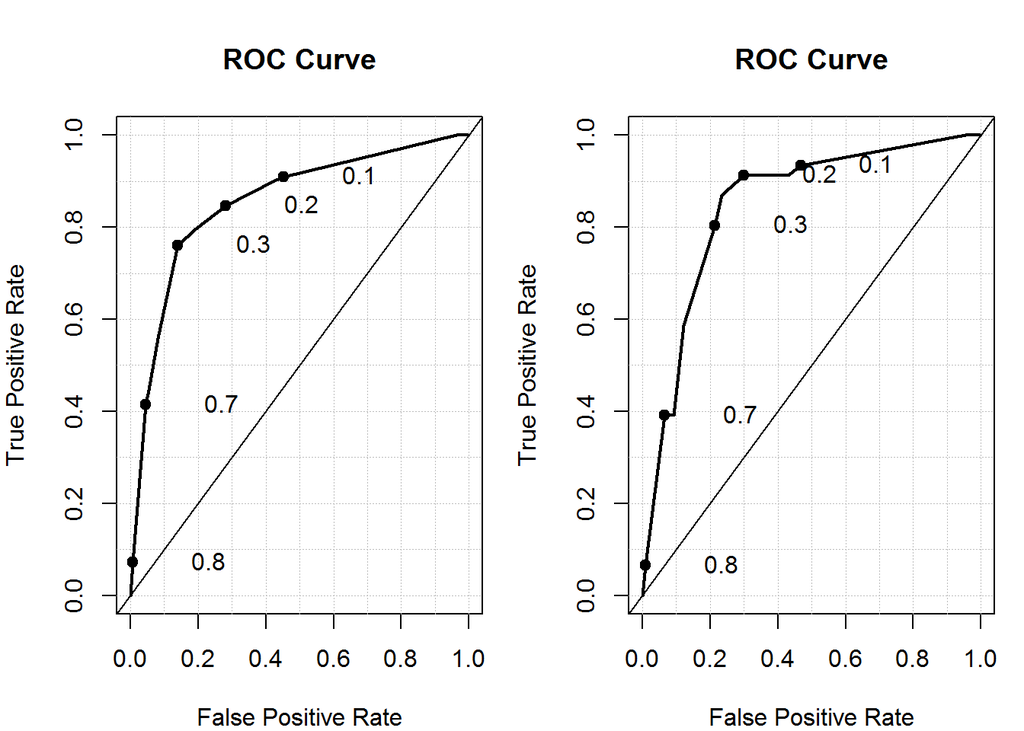

```
##      Model      Area      p.value binorm.area
## 1 Model  1 0.8476229 1.345129e-12          NA
```

```r
roc.plot(test.data$Outcome== "1", tree.pred[,2], ylab = "True Positive Rate", xlab = "False Positive Rate")$roc.vol
```

3. 랜덤 포레스트

```r
# Random Forest Performance
par(mfrow = c(1,2))

rf.predict.in <- predict(rf.model, train.data)
rf.pred.in <- predict(rf.model, train.data,type="prob")
confusionMatrix(train.data$Outcome, rf.predict.in)
```

```
## Confusion Matrix and Statistics
##
##           Reference
## Prediction   0   1
##          0 393   0
##          1   0 222
##
##                Accuracy : 1
##                  95% CI : (0.994, 1)
##     No Information Rate : 0.639
##     P-Value [Acc > NIR] : < 2.2e-16
##
##                   Kappa : 1
##
##  Mcnemar's Test P-Value : NA
##
##             Sensitivity : 1.000
##             Specificity : 1.000
##          Pos Pred Value : 1.000
##          Neg Pred Value : 1.000
##              Prevalence : 0.639
##          Detection Rate : 0.639
##    Detection Prevalence : 0.639
##       Balanced Accuracy : 1.000
##
##        'Positive' Class : 0
##
```

```r
roc.plot(train.data$Outcome == "1", rf.pred.in[,2], ylab = "True Positive Rate", xlab = "False Positive Rate")$roc.vol
```

```
##      Model Area      p.value binorm.area
## 1 Model  1    1 1.036689e-94          NA
```

```r
rf.model<- randomForest(Outcome~., data = train.data, importance=TRUE)
rf.predict.out <- predict(rf.model, test.data)
rf.pred.out <- predict(rf.model, test.data,type="prob")
confusionMatrix(test.data$Outcome, rf.predict.out)
```

```
## Confusion Matrix and Statistics
##
##           Reference
## Prediction  0  1
##          0 93 14
##          1 15 31
##
##                Accuracy : 0.8105
##                  95% CI : (0.7393, 0.8692)
##     No Information Rate : 0.7059
##     P-Value [Acc > NIR] : 0.002179
##
##                   Kappa : 0.5465
##
##  Mcnemar's Test P-Value : 1.000000
##
##             Sensitivity : 0.8611
##             Specificity : 0.6889
##          Pos Pred Value : 0.8692
##          Neg Pred Value : 0.6739
##              Prevalence : 0.7059
##          Detection Rate : 0.6078
##    Detection Prevalence : 0.6993
##       Balanced Accuracy : 0.7750
##
##        'Positive' Class : 0
##
```

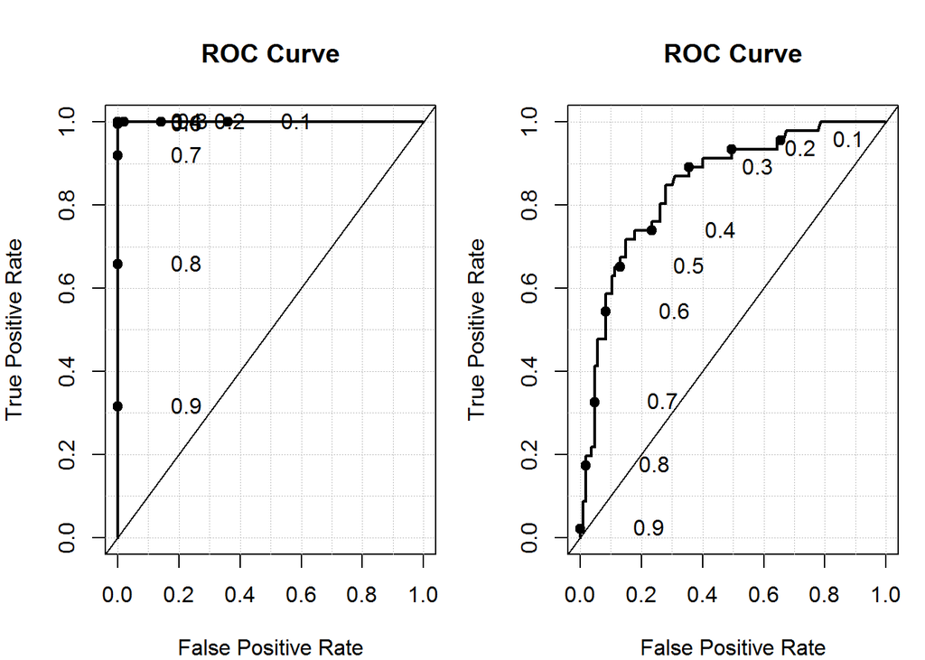

```
##      Model      Area      p.value binorm.area
## 1 Model  1 0.8465055 5.840181e-12          NA
```

```r
roc.plot(test.data$Outcome== "1", rf.pred.out[,2], ylab = "True Positive Rate", xlab = "False Positive Rate")$roc.vol
```

4. SVM

```r
# SVM Performance
par(mfrow = c(1,2))

svm.predict.in <- predict(svm.model, train.data)
svm.pred.in <- predict(svm.model,train.data,probability = TRUE)
confusionMatrix(train.data$Outcome, svm.predict.in)
```

```
## Confusion Matrix and Statistics
##
##           Reference
## Prediction   0   1
##          0 355  38
##          1  87 135
##
##                Accuracy : 0.7967
##                  95% CI : (0.7627, 0.8279)
##     No Information Rate : 0.7187
##     P-Value [Acc > NIR] : 5.589e-06
##
##                   Kappa : 0.5372
##
##  Mcnemar's Test P-Value : 1.761e-05
##
##             Sensitivity : 0.8032
##             Specificity : 0.7803
##          Pos Pred Value : 0.9033
##          Neg Pred Value : 0.6081
##              Prevalence : 0.7187
##          Detection Rate : 0.5772
##    Detection Prevalence : 0.6390
##       Balanced Accuracy : 0.7918
##
##        'Positive' Class : 0
##
```

```r
roc.plot(train.data$Outcome== "1", attr(svm.pred.in, "probabilities")[,2], ylab = "True Positive Rate", xlab = "False Positive Rate")$roc.vol
```

```
##      Model      Area      p.value binorm.area
## 1 Model  1 0.8552484 7.218653e-49          NA
```

```r
svm.predict <- predict(svm.model, test.data)
svm.pred <- predict(svm.model,test.data,probability = TRUE)
confusionMatrix(test.data$Outcome, svm.predict)
```

```
## Confusion Matrix and Statistics
##
##           Reference
## Prediction  0  1
##          0 98  9
##          1 20 26
##
##                Accuracy : 0.8105
##                  95% CI : (0.7393, 0.8692)
##     No Information Rate : 0.7712
##     P-Value [Acc > NIR] : 0.14427
##
##                   Kappa : 0.5163
##
##  Mcnemar's Test P-Value : 0.06332
##
##             Sensitivity : 0.8305
##             Specificity : 0.7429
##          Pos Pred Value : 0.9159
##          Neg Pred Value : 0.5652
##              Prevalence : 0.7712
##          Detection Rate : 0.6405
##    Detection Prevalence : 0.6993
##       Balanced Accuracy : 0.7867
##
##        'Positive' Class : 0
##
```

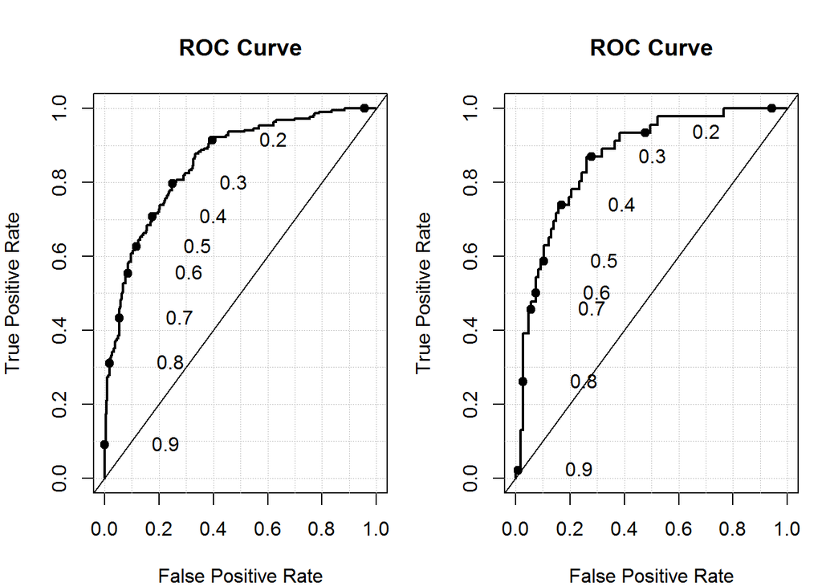

```
##      Model      Area      p.value binorm.area
## 1 Model  1 0.8655018 4.153473e-13          NA
```

```r
roc.plot(test.data$Outcome== "1", attr(svm.pred, "probabilities")[,2], ylab = "True Positive Rate", xlab = "False Positive Rate")$roc.vol
```

# 모든 모델 AUC 비교

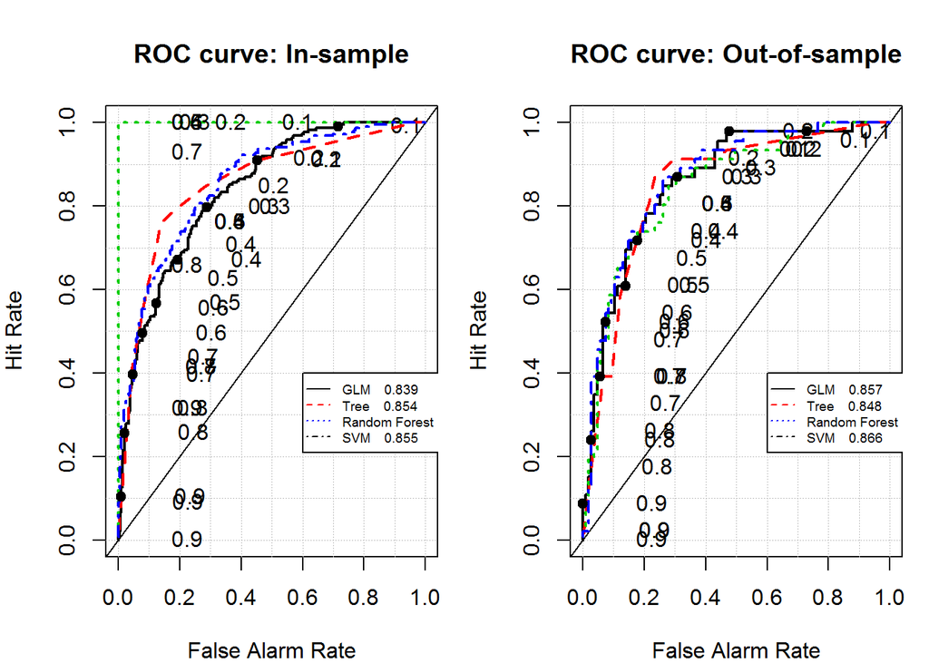

```r
par(mfrow = c(1,2))

# Plot multiple ROC curves in one - Logistic, GAM, Tree and Random Forest
# Compare different models using ROC curves
# In-sample ROC
rocplot1 <- roc.plot(x = (train.data$Outcome == "1"),
                     pred = cbind(pred.in, tree.pred.in[,2], rf.pred.in[,2], attr(svm.pred.in, "probabilities")[,2]),
                     main = "ROC curve: In-sample",
                     legend = T, leg.text = c("GLM","Tree", "Random Forest", "SVM"))
# Validation set ROC
rocplot2 <- roc.plot(x = (test.data$Outcome == "1"),
                     pred = cbind(pred.out, tree.pred[,2], rf.pred.out[,2], attr(svm.pred, "probabilities")[,2]),
                     main = "ROC curve: Out-of-sample",
                     legend = T, leg.text = c("GLM", "Tree", "Random Forest", "SVM"))
```

# 최적의 성능 모델을 결정하기 위한 교차 검증

```r
rocplot1$roc.vol
```

```
##      Model      Area      p.value binorm.area
## 1 Model  1 0.8388923 1.171605e-44          NA
## 2 Model  2 0.8542741 3.193790e-51          NA
## 3 Model  3 1.0000000 1.036689e-94          NA
## 4 Model  4 0.8552484 7.218653e-49          NA
```

```r
rocplot2$roc.vol
```

```
##      Model      Area      p.value binorm.area
## 1 Model  1 0.8571719 1.346698e-12          NA
## 2 Model  2 0.8476229 1.345129e-12          NA
## 3 Model  3 0.8465055 5.840181e-12          NA
## 4 Model  4 0.8655018 4.153473e-13          NA
```

로지스틱 회귀 모델은 PIMA여성에서 당뇨병 발생을 예측하기 위한 가장 좋은 모델로 선정되었는데, 이는 가장 높은 교차 검증 민감도를 보고했기 때문이다.

# 결론

PIMA인도 여성 데이터베이스를 자세히 분석하고 탐색했습니다. 데이터 탐색 방법을 사용하여 식별된 패턴은 채택된 모델링 기법을 사용하여 검증되었습니다. PIMA인디언 여성의 당뇨병 발생을 예측하기 위한 최상의 모델을 식별하기 위해 로지스틱 회귀 분석, 분류 트리, 랜덤 포리스트 및 SVM과 같은 분류 모델을 구축하고 평가하였습니다. 민감도의 교차 검증된 성과 측정에서, 로지스틱 회귀 분석 모델은 가장 우수한 성과 모델로 결론지었습니다.